# MAF: Visualization of somatic mutations

Florencia Zuniga

7/17/2019

Which types of mutations affect affect the genes we explore in this analysis? Can we exploit this information to know which types of therapy might be effective? This analysis will focus on visualizing the somatic mutations of several genes and the samples they affect. We aim to find differences in patterns of mutations when we consider all genes and when we consider only 100 biomarkers.

1. LOADING DATA

2. Creation of polished MAF files

- 2.1 Creation of a polished MAF file for all genes
- 2.2 Creation of a polished MAF file for 100 Biomarkers

2. General visualizations

- 2.1 Summaries of both MAF files)
- 2.2 Oncoplots and oncostrips
- 2.4 Somatic interactions with oncostrips

3. Drug-gene interactions: which types of therapy should be considered with the given mutations

- 3.1 Druggable categories)
- 3.2 Pathways

4. References

## 1. LOADING DATA

### Loading packages

```r
library(readr)
library(rstudioapi)
library(maftools)
```

Reading the data

```r
# Reading the data
Untreated <- readRDS(paste0(wd,"/data/NCI_TPW_gep_untreated.rds"))
Treated <- readRDS(paste0(wd,"/data/NCI_TPW_gep_treated.rds"))

Metadata = read.table(paste0(wd,"/data/NCI_TPW_metadata.tsv"),
                      header = TRUE, sep ="\t", stringsAsFactors = TRUE)

Sensitivity <- readRDS(paste0(wd,"/data/NegLogGI50.rds"))


Basal <- readRDS(paste0(wd,"/data/CCLE_basalexpression.rds"))
Copynumber <- readRDS(paste0(wd,"/data/CCLE_copynumber.rds"))
Mutations <- readRDS(paste0(wd,"/data/CCLE_mutations.rds"))

Metadata = read.table(paste0(wd,"/data/NCI_TPW_metadata.tsv"), header = TRUE, sep ="\t", stringsAsFactors = TRUE)

Cellline_annotation = read.table(paste0(wd,"/data/cellline_annotation.tsv"),
                                 header = TRUE, sep ="\t", stringsAsFactors = TRUE)
Drug_annotation = read.table(paste0(wd,"/data/drug_annotation.tsv"),
                             header = TRUE, sep ="\t", stringsAsFactors = TRUE)

# Transforming the data

Treated <- as.data.frame(Treated)
Untreated <- as.data.frame(Untreated)
Sensitivity<- as.data.frame(Sensitivity)
```

Data normalization

```r
Untreated_norm <- apply(Untreated, 2, function(x){
  (x - mean(x)) / sd(x)
 })


Treated_norm <- apply(Treated, 2, function(x){
  (x - mean(x)) / sd(x)
 })


FC <- Treated - Untreated
FC_norm <- apply(FC, 2, function(x){
  (x - mean(x)) / sd(x)
 })
```

## 2. Creation of polished MAF files

For the ‘CCLE_mutations’ file to be read using the ‘maftools’ package, we must first edit it so that the resultung ‘table’ has all the mandatory columns.

```r
Mutations <- readRDS(paste0(wd,"/data/CCLE_mutations.rds"))

names(Mutations)[names(Mutations) == "Tumor_Seq_Allele1"] <- "Tumor_Seq_Allele2"
names(Mutations)[names(Mutations) == "Start_position"] <- "Start_Position"
names(Mutations)[names(Mutations) == "End_position"] <- "End_Position"
rownames(Mutations) <- c()
MutationsT <- Mutations[,c(1,4,5,6,10,11,8,9,16,2,3,7,12,13,14,15,17,18)]
```

### 2.1 Creation of a polished MAF file for all genes

```r
write.table(MutationsT, file = "MutationsT.csv", row.names = F, sep = "\t")

laml <- read.maf(maf ="C:/GitHub/project-02-group-05/MutationsT.csv", useAll = T, verbose = T)
```

### 2.2 Creation of a polished MAF file for 100 biomarkers

To create this table, the biomarkers found using the fold change in the first part of the specific analysis are used.

```r
BM_mut = MutationsT[ which((MutationsT$Hugo_Symbol)
                                  %in% rownames(biomarkers_FC_values100)), ]

write.table(BM_mut, file = "BM_mut.csv", row.names = F, sep = "\t")

BM_laml <- read.maf(maf ="C:/GitHub/project-02-group-05/BM_mut.csv", useAll = T, verbose = T)
```

## 2. General visualizations

### 2.1 Summaries of both MAF files

To begin our analysis, we visualize different plots that summarize the most important informations.

**Summary for all genes**

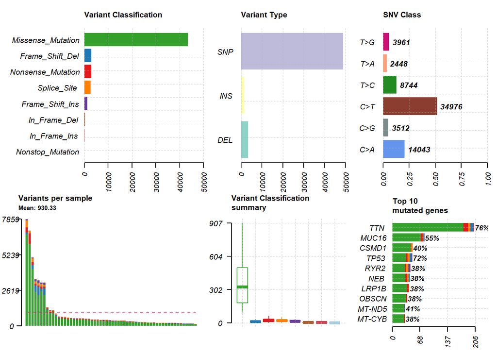

```r
plotmafSummary(maf = laml,
               rmOutlier = TRUE,
               addStat = 'mean',
               dashboard = TRUE,
               titvRaw = FALSE)
```

**Summary for the biomarker genes**

As the code for some plots only differs in the MAF file that is to be read or other small details, only the plots and not the code is shown in those cases to avoid redundancy.

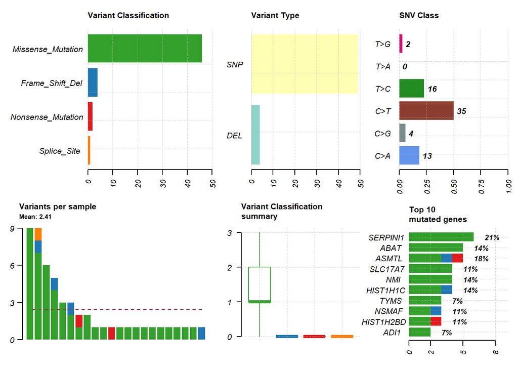

We can already observe that plenty of differences arise when we consider all genes vs 100 biomarkers. Although the most common type of mutation is the missense one in both cases, in the summary of all genes more types of mutations affect the genes in the samples. Only 4 distinct type of mutations can be observed for the biomarkers.

Another interesting observation, is that when all genes are considered, there are mutations that happen because of an insertion. This is no longer true when we only consider the biomarkers. However, in both cases the variant type plot shows that the most common type of variation is the single nucleotide polymorphism.

If we look at the plot ‘Variants per sample’ in both summaries, another surprising result is that there is a drastic change in the mean. This is probably a result of less variation of variation when we consider only the biomarkers, as we would hope those genes would act in a similar way, because the biomarkers are the most affected genes by vorinostat in general in all samples.

The top 10 mutated genes are all different in the two summaries. It is worth nothing that 2 of the top ten genes affected when only considering the biomarkers are related to the expression of histones. These genes are **HIST1H1C**, which encodes the protein Histone H1.2, and the gene **HIST1H2BD**, which encodes the protein Histone H2B type 1-D. This finding is of particular relevance, because the mechanisms of vorinostat is to inhibit HDACs.

### 2.2 Oncoplots and oncostrips

We can also plot the top n genes that shows the most variation in the samples. For this, we use waterfall plots that show the different mutations that affect each sample on the top, the percentage of samples that have been affected by mutations in certain genes on the right, the names of the mutated genes on the left and the transitions/transversions of nucleotides per sample on the bottom.

#### Ploting oncoplot with Transversions/Transitions

**All genes**

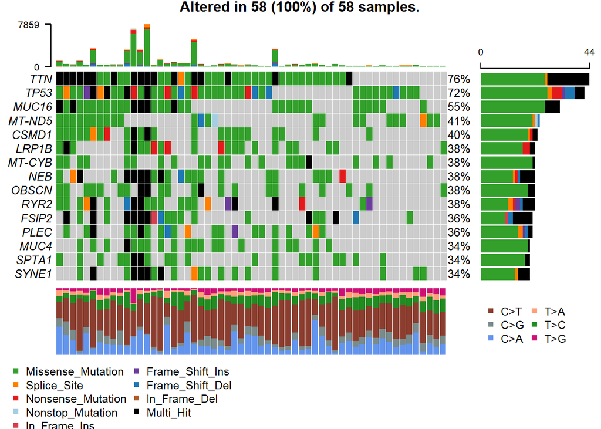

```r
oncoplot(maf = laml, top = 15, draw_titv = TRUE)
```

As all the samples we are handling are of cancerous nature, all of them have mutations in one or several genes, with the most common mutation being a missense one and the most common transition of nucleotide being the one from cytosine to thymine.

**Biomarker genes**

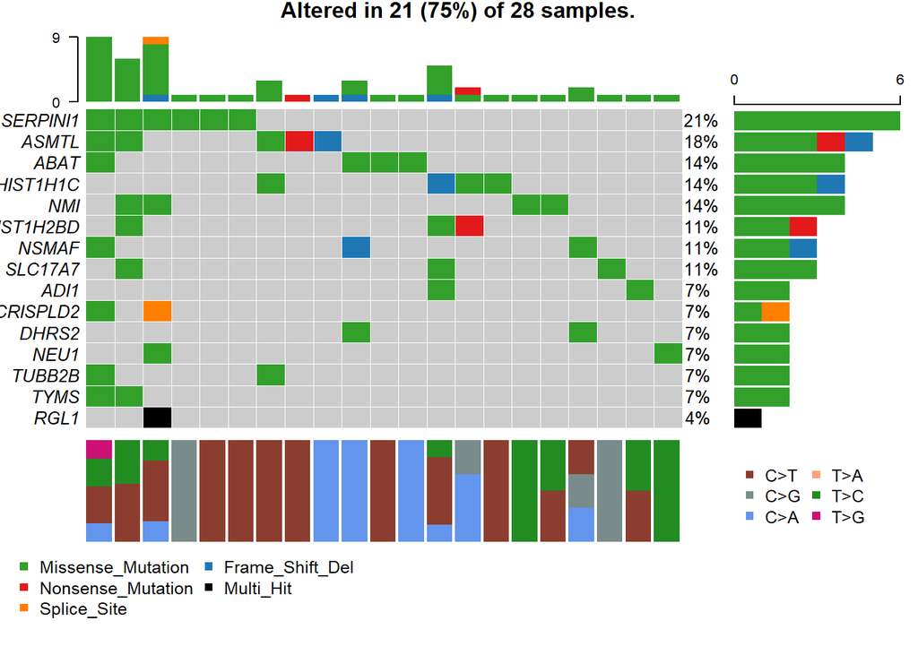

When we consider only the biomarkers, within the top 15 genes there are only 21 samples that are mutated. What is also interesting, is that when we consider 100 biomarkers only 28 samples of the 58 that were studied in total show some type of mutation. There is less variation in the type of mutations than in the previous oncoplot. Most biomarkers have one or several missense mutations, with other kinds of mutations appearing only rarely.

#### Oncostrips

Are there mutational differences between the top 10 biomarkers and the 10 genes with the least change in expression? These genes are obtained from the matrixes in the first part of the specific analysis when the biomarkers were found.

##### **Oncostrip of the top 10 biomarkers**

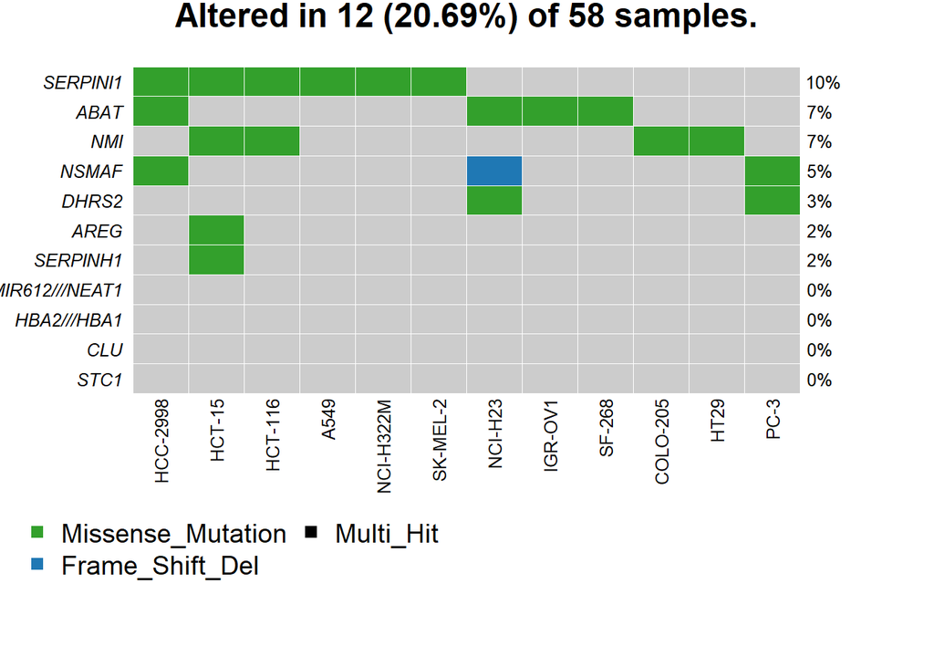

```r
oncostrip(maf = laml,
          genes = c('DHRS2',
                    'ABAT',
                    'SERPINI1',
                    'MIR612///NEAT1 ',
                    'HBA2///HBA1    ',
                    'CLU',
                    'NMI',
                    'STC1',
                    'AREG',
                    'NSMAF',
                    'SERPINH1'),
          showTumorSampleBarcodes = TRUE,
          SampleNamefontSize = 0.8
          )
```

##### **Oncostrips for the 10 genes with the least change in expression**

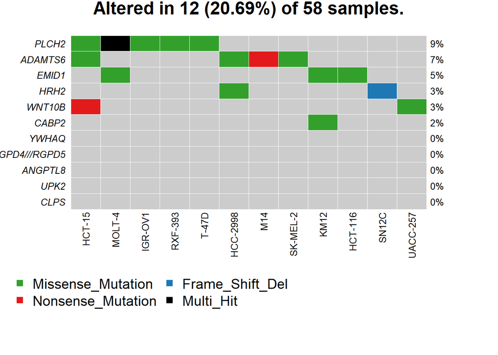

The results we observe in these plots coincide with our previous findings: when we consider the biomarkers, in this case the top 10, most of them are affected by missense mutations, which are point mutations that causes the formation of a codon that codes for a different aminoacid. The second oncostrip shows more variation in the types of mutation present.

### 2.3 Somatic interactions with oncostrips

**All genes**

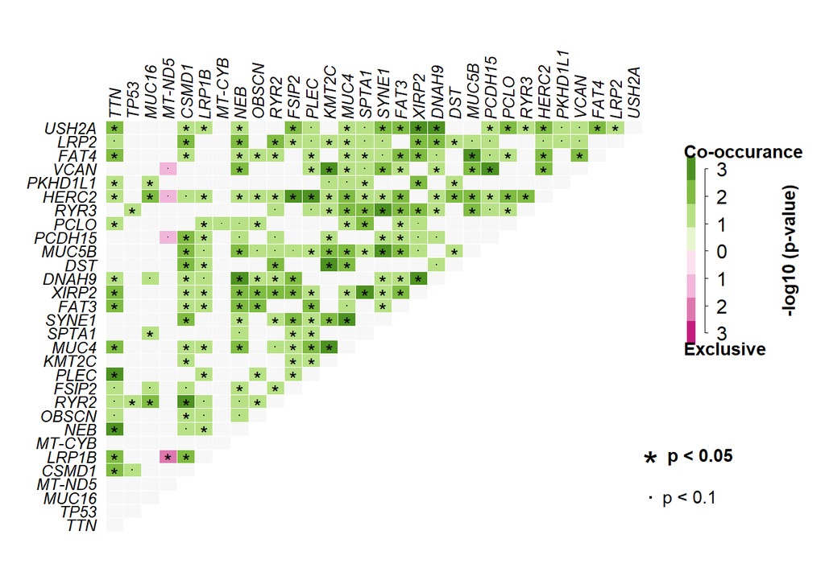

```
## Checking for Gene sets
## ------------------
## genes: 5
## geneset size: 3
## 10 combinations
## Signifcantly altered gene-sets: 1
## ------------------
```

```
## $pairs
##       gene1  gene2       pValue  oddsRatio 00 11 01 10              Event
##   1:  USH2A  XIRP2 5.504229e-05 14.0423124 35 12  7  4       Co_Occurance
##   2:   VCAN PCDH15 6.595420e-05 13.1259785 35 12  6  5       Co_Occurance
##   3:   MUC4  KMT2C 8.051493e-05 11.7362366 32 14  6  6       Co_Occurance
##   4:   RYR2  CSMD1 8.669148e-05 10.4728993 29 16  7  6       Co_Occurance
##   5:   RYR3  SYNE1 1.677523e-04 11.5616537 33 13  7  5       Co_Occurance
##  ---
## 224: MT-ND5  HERC2 8.850156e-02  0.3292542 21  4 13 20 Mutually_Exclusive
## 225: MT-ND5   VCAN 8.850156e-02  0.3292542 21  4 13 20 Mutually_Exclusive
## 226:  DNAH9  MUC16 9.514840e-02  2.8219382 21 13 19  5       Co_Occurance
## 227:    NEB  CSMD1 9.834834e-02  2.6777301 25 12 11 10       Co_Occurance
## 228:  MUC16  FSIP2 9.862900e-02  2.8861297 20 15  6 17       Co_Occurance
##
## $gene_sets
##                 gene_set     pvalue
## 1: LRP1B, PCDH15, MT-ND5 0.04964611
```

```r
somaticInteractions(maf = laml, top = 30, pvalue = c(0.05, 0.1))
```

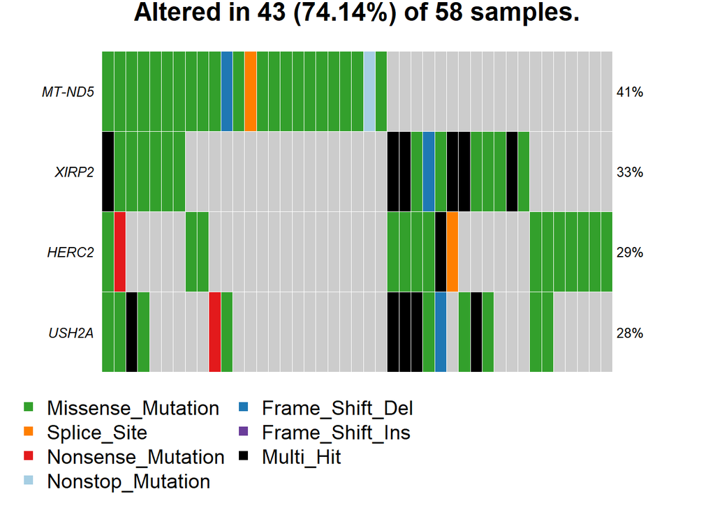

```r
oncostrip(maf = laml, genes = c('USH2A', 'XIRP2','MT-ND5', 'HERC2'))
```

**Biomarker genes**

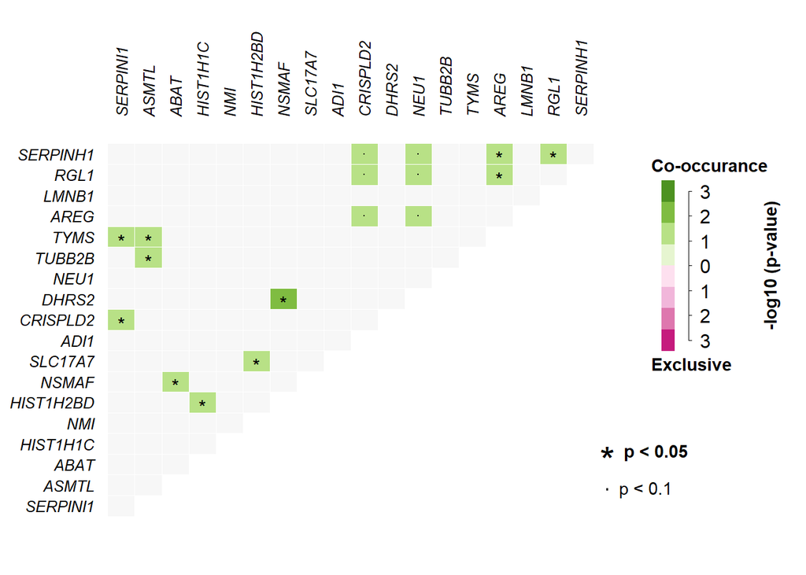

```
## $pairs
##         gene1     gene2      pValue oddsRatio 00 11 01 10        Event
##  1:     NSMAF     DHRS2 0.007936508       Inf 25  2 NA  1 Co_Occurance
##  2:   SLC17A7 HIST1H2BD 0.023199023  32.27712 24  2  1  1 Co_Occurance
##  3:    TUBB2B     ASMTL 0.026455026       Inf 23  2  3 NA Co_Occurance
##  4:      TYMS     ASMTL 0.026455026       Inf 23  2  3 NA Co_Occurance
##  5:      RGL1      AREG 0.035714286       Inf 27  1 NA NA Co_Occurance
##  6:  SERPINH1      AREG 0.035714286       Inf 27  1 NA NA Co_Occurance
##  7:  SERPINH1      RGL1 0.035714286       Inf 27  1 NA NA Co_Occurance
##  8:  CRISPLD2  SERPINI1 0.039682540       Inf 22  2  4 NA Co_Occurance
##  9:      TYMS  SERPINI1 0.039682540       Inf 22  2  4 NA Co_Occurance
## 10:     NSMAF      ABAT 0.045177045  18.20480 23  2  2  1 Co_Occurance
## 11: HIST1H2BD  HIST1H1C 0.045177045  18.20480 23  2  2  1 Co_Occurance
## 12:      AREG  CRISPLD2 0.071428571       Inf 26  1  1 NA Co_Occurance
## 13:      RGL1  CRISPLD2 0.071428571       Inf 26  1  1 NA Co_Occurance
## 14:  SERPINH1  CRISPLD2 0.071428571       Inf 26  1  1 NA Co_Occurance
## 15:      AREG      NEU1 0.071428571       Inf 26  1  1 NA Co_Occurance
## 16:      RGL1      NEU1 0.071428571       Inf 26  1  1 NA Co_Occurance
## 17:  SERPINH1      NEU1 0.071428571       Inf 26  1  1 NA Co_Occurance
##
## $gene_sets
## NULL
```

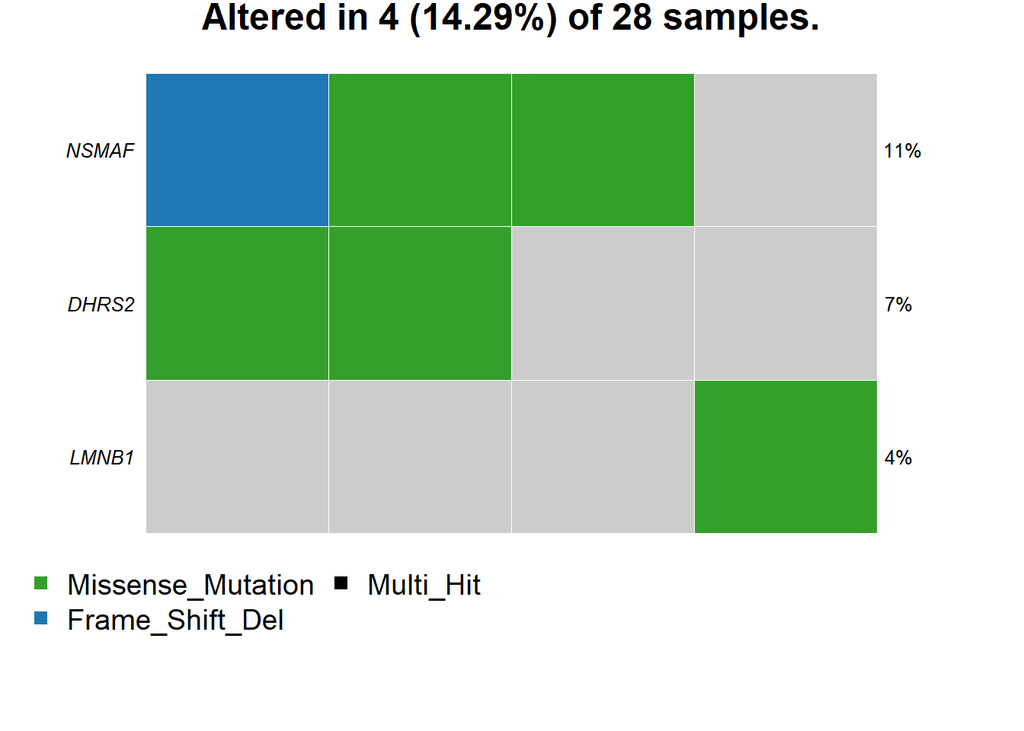

## 3. Drug-gene interactions: which types of therapy should be considered with the given mutations

### 3.1 Druggable categories

**All genes**

```r
dgi = drugInteractions(maf = laml, fontSize = 0.75)
```

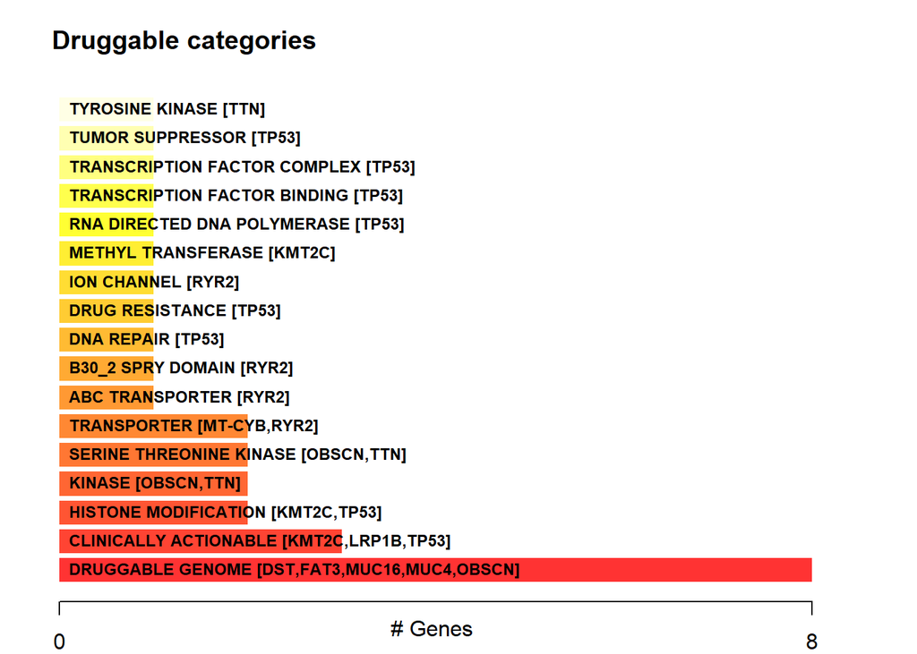

```r
dnmt3a.dgi = drugInteractions(genes = "LRP1B", drugs = TRUE)
```

```
## Number of claimed drugs for given genes:
##     Gene N
## 1: LRP1B 2
```

```r
dnmt3a.dgi[,.(Gene, interaction_types, drug_name, drug_claim_name)]
```

```
##     Gene interaction_types   drug_name       drug_claim_name
## 1: LRP1B                               Liposomal Doxorubicin
## 2: LRP1B                   DOXORUBICIN           DOXORUBICIN
```

**Biomarker genes**

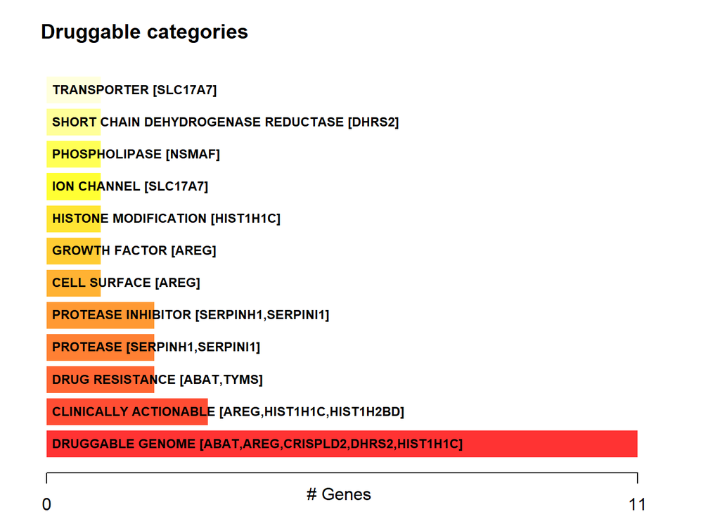

### 3.2 Pathways

**All genes**

```r
OncogenicPathways(maf = laml)
```

```
## Pathway alteration fractions
```

```
##        Pathway  N n_affected_genes fraction_affected
##  1:    RTK-RAS 85               78         0.9176471
##  2:        WNT 68               60         0.8823529
##  3:      NOTCH 71               60         0.8450704
##  4:      Hippo 38               35         0.9210526
##  5:       PI3K 29               25         0.8620690
##  6: Cell_Cycle 15               14         0.9333333
##  7:        MYC 13               11         0.8461538
##  8:   TGF-Beta  7                7         1.0000000
##  9:       TP53  6                6         1.0000000
## 10:       NRF2  3                3         1.0000000
```

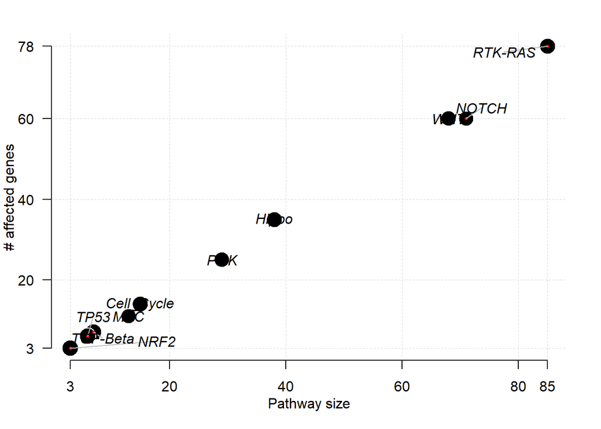

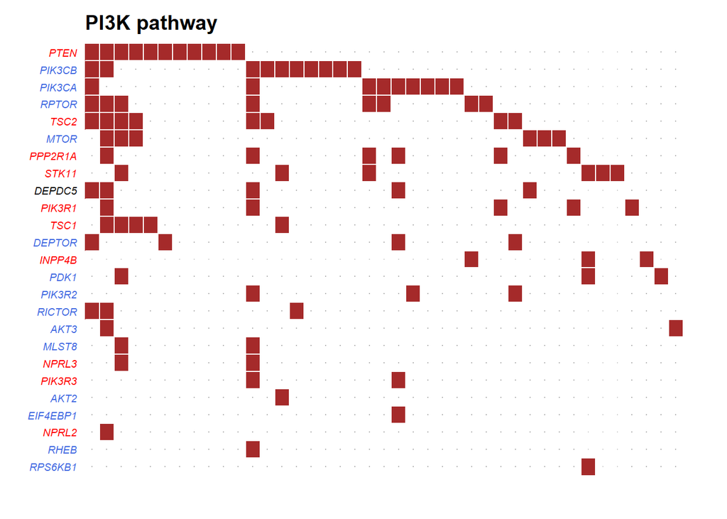

```r
PlotOncogenicPathways(maf = laml, pathways = "PI3K")
```

**Biomarker genes**

```
## Pathway alteration fractions
```

```
##        Pathway  N n_affected_genes fraction_affected
##  1: Cell_Cycle 15                0                 0
##  2:      Hippo 38                0                 0
##  3:        MYC 13                0                 0
##  4:      NOTCH 71                0                 0
##  5:       NRF2  3                0                 0
##  6:       PI3K 29                0                 0
##  7:    RTK-RAS 85                0                 0
##  8:   TGF-Beta  7                0                 0
##  9:       TP53  6                0                 0
## 10:        WNT 68                0                 0
```

## 4. References

Gene Cards. 2019. GeneCards®: The Human Gene Database. [ONLINE] Available at: https://www.genecards.org/. [Accessed 17 July 2019].

National Human Genome Research Institute. 2019. Missense Mutation. [ONLINE] Available at: https://www.genome.gov/genetics-glossary/Missense-Mutation. [Accessed 17 July 2019].